# 00_getting_started slides

Computational Finance and FinTech  
M.Sc. International Finance

[figure not shown]

Prof. Dr. Natalie Packham  
Berlin School of Economics and Law  
Summer Term 2019

- A lot of important information about the course can be found in the **syllabus** on the course’s Moodle webpage.
- The lecture script mainly follows the textook **Python for Finance (2nd edition)** by Yves Hilpisch.
- The book is available as an **ebook** from the HWR library ([link](https://ebookcentral.proquest.com/lib/hwr/detail.action?docID=5612855)).
- I am grateful to **Yves Hilipsch** ([The Python Quants Group](https://tpq.io)) for letting me use his code and material.
- References to the book are abbreviated as **Py4Fi**.
- For example, along with this introductory chapter you may want to consult **Py4Fi, Ch. 1**.

# Contents

# Getting started

### Background

- Python is an open-source programming language that can be downloaded and used for free.
- Python was created by Guido van Rossum and first published in 1991.
- Today the language is largely developed by the Python Software Foundation, a nonprofit organization.
- It is named after the British comedy group "Monty Python".

### Features

- Open source
- Interpreted, i.e., code is compiled at runtime
- Multiparadigm (supports e.g. object orientation)
- Multipurpose, i.e., it is used for rapid prototyping as well as production systems
- Cross-platform (runs on Windows, Linux, MacOS, ...)
- Dynamically typed (types are inferred by the Python interpreter)
- Indentation aware (indentation is used instead of braces to mark code blocks)
- Garbage collection (automated memory management)

```python
import this
```

```
The Zen of Python, by Tim Peters

Beautiful is better than ugly.
Explicit is better than implicit.
Simple is better than complex.
Complex is better than complicated.
Flat is better than nested.
Sparse is better than dense.
Readability counts.
Special cases aren't special enough to break the rules.
Although practicality beats purity.
Errors should never pass silently.
Unless explicitly silenced.
In the face of ambiguity, refuse the temptation to guess.
There should be one-- and preferably only one --obvious way to do it.
Although that way may not be obvious at first unless you're Dutch.
Now is better than never.
Although never is often better than *right* now.
If the implementation is hard to explain, it's a bad idea.
If the implementation is easy to explain, it may be a good idea.
Namespaces are one honking great idea -- let's do more of those!
```

Many examples and extended information can be found on the following websites:

- [Beginners' Guide](https://wiki.python.org/moin/BeginnersGuide)
- [Python.org](https://docs.python.org/3/tutorial/)
- [Scipy Lectures](http://scipy-lectures.org/_downloads/ScipyLectures-simple.pdf)
- [The Hitchhiker’s Guide to Python](https://docs.python-guide.org)

### Pros

- **Universal**: Python runs on any operating system.
- **Easy to learn**: Although Python is highly versatile (e.g. can be used for scientific computing), it is relatively easy to learn.
- **Readable code**: Python is a high-level programming language, making it easy to read and work with.
- **General purpose**: The language can be applied to solve different problems at hand.

### Cons

- **Speed**: While Python is not slow, it cannot keep up with compiled languages such as C, C++, Fortran, COBOL, etc.

# Installing Python and Jupyter Notebook

### Setting up Python for this class

- There are two major versions of Python: Python 2 and Python 3. We will use **Python 3.7** in this class.
- Easiest method:
  - Install [Anaconda](https://www.anaconda.com); this will setup up **Python** as well as the **Jupyter Notebook** environment that we are going to use in class.

### Jupyter Notebook

- **Jupyter Notebook** is a browser-based application used for creating and sharing documents, containing live code, visualizations, equations, plain text, and many other features.
- Launch Jupyter Notebook:
  - from Anaconda or
  - from the command line (`Terminal` in MacOs or `cmd` in Windows) using the command

    ```
    jupyter notebook
    ```

- Jupyter notebooks run in a local webserver.

### Jupyter Notebook

- Before launching Jupyter Notbook from the command line you may wish to navigate to the directory where the notebooks are stored or where you want to store them.
- To open a new notebook click on "New" and "Python 3" in the Jupyter Notebook main window.
- To learn to use Jupyter Notebook before, click on "Help" and "User Interface Tour".

### Other ways to run Python

- The Python **shell**: call `python` from a shell or start an online version at [online shell](https://www.python.org/shell/)

[figure not shown]

### Other ways to run Python

- Run Python scripts (suffix `.py`) from a command line using the `python` command, e.g. `python file.py`.
- Python’s **IDLE** (Integrated Development and Learning Environment) is another basic shell to run Python commands.
- An **IDE** (Integrated Development Environment) is an application that integrates programming, running code, debugging, etc.
- **IPython**: Interactive Python shell.

### The Python Ecosystem

- Aside from the programming language, there is a large number of packages, modules and other tools available to support specific tasks.
- For example, various plotting libraries are available and can be readily used using `import`.

### The Python Ecosystem

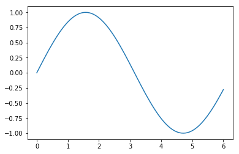

```python
import numpy as np
import math
import matplotlib.pyplot as plt

x = np.linspace(0, 6, 100);
y = np.sin(x);
plt.plot(x, y);
```

### Popular packages ("The scientific stack")

- [`NumPy`](http://www.numpy.org): multidimensional array objects
- [`SciPy`](http://www.scipy.org): functionality often needed in science or finance
- [`matplotlib`](http://www.matplotlib.org): plotting
- [`pandas`](http://pandas.pydata.org): times series and tabular data
- [`scikit-learn`](http://scikit-learn.org): machine learning package
- [`PyTables`](http://www.pytables.org): data storage package

# A first example

### Example load and plot financial data

- The following code imports the packages that will be used and sets up the plotting library.

```python
import numpy as np
import pandas as pd
from pylab import plt, mpl

plt.style.use('seaborn')
mpl.rcParams['font.family'] = 'serif'
%matplotlib inline
```

### Example load and plot financial data

- The following code imports a time series of S&P 500 index data from a `csv` file (`csv`=comma separated values).
- It also shows information about the time series.

```python
data = pd.read_csv('_src/tr_eikon_eod_data.csv',
                  index_col=0, parse_dates=True)
data = pd.DataFrame(data['.SPX'])
data.dropna(inplace=True)
data.info()
```

```
<class 'pandas.core.frame.DataFrame'>
DatetimeIndex: 2138 entries, 2010-01-04 to 2018-06-29
Data columns (total 1 columns):
.SPX    2138 non-null float64
dtypes: float64(1)
memory usage: 33.4 KB
```

### Example load and plot financial data

- Transform the index level data to log-returns, estimate volatility (=standard deviation of returns) and produce plots of index and volatility.

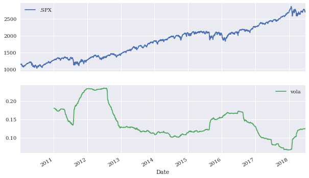

```python
data['rets'] = np.log(data / data.shift(1))
data['vola'] = data['rets'].rolling(252).std() * np.sqrt(252)

data[['.SPX', 'vola']].plot(subplots=True, figsize=(10, 6));
```